# Code Documentation for ‘Automated Analysis of Low-Field Brain MRI in Cerebral Malaria’

Code Documentation

Danni Tu

May 13, 2022

This document contains the analyses from the paper titled “Automated Analysis of Low-Field Brain MRI in Cerebral Malaria” (Tu et al. 2020) [(bioRxiv link)](https://www.biorxiv.org/content/10.1101/2020.12.23.424020v3). The goal of this paper is to automate the classification of brain images in children with cerebral malaria using 0.35T MRI. We pre-processed the images, constructed biomarkers of severe brain swelling, and employed a logistic regression model to predict severe cases of cerebral edema. Specifically, our pipeline consists of the following steps:

1. Pre-processing
   1. N4 Bias Correction (Tustison et al. 2010)
   2. Multi-atlas Label Fusion (Doshi et al. 2013)
2. Biomarkers
   1. Parenchymal Brain Fraction
   2. WhiteStripe Intensity (Shinohara et al. 2014)
   3. Hessian Filter (Frangi et al. 1998)
3. Prediction of severe brain swelling

# Setup

To use this pipeline on your own data, you will need the following:

1. A T1- and T2-weighted MRI image for each participant
2. Brain atlases (open access option for pediatric atlases: http://nist.mni.mcgill.ca/pediatric-atlases-4-5-18-5y/)
3. Ventricle atlases (open access option for adult atlases: https://www.oasis-brains.org/#data)

You will also need to install the following open-source software:

1. ANTs ([http://stnava.github.io/ANTs/[http://stnava.github.io/ANTs/](http://stnava.github.io/ANTs/%5Bhttp://stnava.github.io/ANTs/)])
2. FSL ([https://fsl.fmrib.ox.ac.uk/fsl/fslwiki/[https://fsl.fmrib.ox.ac.uk/fsl/fslwiki/](https://fsl.fmrib.ox.ac.uk/fsl/fslwiki/%5Bhttps://fsl.fmrib.ox.ac.uk/fsl/fslwiki/)])

```r
# Image processing
library(ANTsR)
library(extrantsr)
library(neurobase)
library(fslr)
library(WhiteStripe)

# Table/Figure formatting
library(stargazer)
library(pander)
library(gridExtra)

# Data analysis
library(parallel)
library(pROC)
library(caret)
library(MLeval)
library(tidyverse)
```

```r
# Number of cores for parallel processing
n_cores = 6

# Set location of the raw data
# dir_cm = [set this to the folder containing all directories]
dir_nifti_train = file.path(dir_cm, "Training Set/NIFTI/") # Location of Train NIFTIs
dir_nifti_test = file.path(dir_cm, "Test Set/NIFTI/") # Location of Test NIFTIs

dir_pnc = file.path(dir_cm, "PNC_Atlases") # Location of PNC Atlases

dir_oasis = file.path(dir_cm, "OASIS_Atlases") # Location of OASIS Atlases
```

```r
# Overall helper functions

# Create a specified folder, print message otherwise
make_folder <- function(folder_name){
  folder_name = paste0(folder_name)
  if (!dir.exists(folder_name)){
    dir.create(folder_name)
  } else {
    message(paste0("Folder ", folder_name, " already exists"))
  }
}

# Print pandoc table
pt <- function(tab){
  tab %>% pandoc.table(split.table = Inf)
}

# Get the subject ID from any filename
# (Adapt this to your own filenames)
find_name <- function(strs){

  strs %>%
    map(~gsub(pattern = "mv_", replacement = "", x = .x)) %>%
    map(~str_split(string = nii.stub(.x, bn = TRUE), pattern = "_")[[1]][1]) %>%
    unlist

}
```

# 1 Pre-processing

First, we set up our folders and ensure that all of our MRI images and atlases are at the correct location. In our data, participants were split into Training/Test sets at the outset. If your images are all in one folder, simply ignore the lines with `dir_nifti_test`.

```r
# Make directories and add input files

make_folder(file.path(dir_nifti_train, "T1"))
make_folder(file.path(dir_nifti_train, "T2"))
make_folder(file.path(dir_nifti_train, "T1/Raw_Uncorrected")) # Put Raw T1 NIFTI images here
make_folder(file.path(dir_nifti_train, "T2/Raw_Uncorrected")) # Put Raw T2 NIFTI images here
make_folder(file.path(dir_nifti_train, "atlas"))
make_folder(file.path(dir_nifti_train, "mask"))

make_folder(file.path(dir_nifti_test, "T1"))
make_folder(file.path(dir_nifti_test, "T2"))
make_folder(file.path(dir_nifti_test, "T1/Raw_Uncorrected")) # Put Raw T1 NIFTI images here
make_folder(file.path(dir_nifti_test, "T2/Raw_Uncorrected")) # Put Raw T2 NIFTI images here
make_folder(file.path(dir_nifti_test, "atlas"))
make_folder(file.path(dir_nifti_test, "mask"))

make_folder(file.path(dir_pnc, "atlas"))
make_folder(file.path(dir_pnc, "mask")) # PNC brain masks go here; no bias correction for masks
make_folder(file.path(dir_pnc, "atlas/Raw_Uncorrected")) # PNC brain atlases go here

make_folder(file.path(dir_oasis, "atlas"))
make_folder(file.path(dir_oasis, "mask")) # OASIS ventricle masks go here; no bias correction for masks
make_folder(file.path(dir_oasis, "atlas/Raw_Uncorrected")) # OASIS ventricle atlases go here

make_folder(file.path(dir_cm, "Biomarkers"))
```

## 1.1 N4 Bias Correction

```r
# fname: complete name and path of NIFTI file
# out_dir: directory to save the bias corrected images
bias_correction <- function(fname, out_dir){
  temp <- readnii(fname) %>%
    bias_correct(correction = "N4")

  antsImageWrite(temp, filename = file.path(out_dir, basename(fname)))
}

# Bias correct all MRI images
list.files(file.path(dir_nifti_train, "T1/Raw_Uncorrected"), full.names = TRUE) %>%
  map(bias_correction, out_dir = file.path(dir_nifti_train, "T1"))
list.files(file.path(dir_nifti_train, "T2/Raw_Uncorrected"), full.names = TRUE) %>%
  map(bias_correction, out_dir = file.path(dir_nifti_train, "T2"))

list.files(file.path(dir_nifti_test, "T1/Raw_Uncorrected"), full.names = TRUE) %>%
  map(bias_correction, out_dir = file.path(dir_nifti_test, "T1"))
list.files(file.path(dir_nifti_test, "T2/Raw_Uncorrected"), full.names = TRUE) %>%
  map(bias_correction, out_dir = file.path(dir_nifti_test, "T2"))

# Bias correct all PNC Atlases
list.files(file.path(dir_pnc, "atlas/Raw_Uncorrected"), full.names = TRUE) %>%
  map(bias_correction, out_dir = file.path(dir_pnc, "atlas"))

# Bias correct all OASIS Atlases
list.files(file.path(dir_oasis, "atlas/Raw_Uncorrected"), full.names = TRUE) %>%
  map(bias_correction, out_dir = file.path(dir_oasis, "atlas"))
```

## 1.2 Multi-Atlas Label Fusion

### 1.2.1 Register brain atlases/masks to T1

```r
# Make directories for MALF output
make_folder(file.path(dir_nifti_train, "atlas/MALF"))
make_folder(file.path(dir_nifti_train, "mask/MALF"))

make_folder(file.path(dir_nifti_test, "atlas/MALF"))
make_folder(file.path(dir_nifti_test, "mask/MALF"))

# Not called directly
# fname: filename of the target image
# atlas_files/mask_files: vector of filepaths
# atlas_outfolder/mask_outfolder: location to save the registered atlases and masks
register_it <- function(fname, atlas_files, mask_files, atlas_outfolder, mask_outfolder){
  tar_name = nii.stub(fname, bn = TRUE)

  # Register everything to reg_base
  reg_base = readnii(fname)

  # Create run_folder if it doesn't already exist
  reg_base_dir_a = paste0(atlas_outfolder, "/", tar_name, "/")
  reg_base_dir_m = paste0(mask_outfolder, "/", tar_name, "/")

  make_folder(reg_base_dir_a)
  make_folder(reg_base_dir_m)

  message(paste0("Registering to ", tar_name))

  # For each raw atlas and mask... register it to target[j]
  for (j in 1:length(atlas_files)){
    atlas_filepath = atlas_files[j]
    mask_filepath = mask_files[j]

    # Check atlas/mask match
    stopifnot(grepl(nii.stub(atlas_filepath, bn = TRUE) %>% gsub(pattern = "mprage_LPS", replacement = ""),
                    nii.stub(mask_filepath, bn = TRUE)))

    # Registration
    atlas_to_image = registration(filename = atlas_filepath,
                                  correct = FALSE,
                                  template.file = reg_base,
                                  typeofTransform = "SyN", remove.warp = FALSE,
                                  verbose = FALSE)

    # Apply transform to atlas and mask
    atlas_reg = antsApplyTransforms(fixed = oro2ants(reg_base),
                                    moving = oro2ants(readnii(atlas_filepath)),
                                    transformlist = atlas_to_image$fwdtransforms,
                                    interpolator = "nearestNeighbor")
    mask_reg = antsApplyTransforms(fixed = oro2ants(reg_base),
                                   moving = oro2ants(readnii(mask_filepath)),
                                   transformlist = atlas_to_image$fwdtransforms,
                                   interpolator = "nearestNeighbor")

    # Outfile names
    atlas_out_dir = paste0(reg_base_dir_a, "/reg_", basename(atlas_filepath))
    mask_out_dir = paste0(reg_base_dir_m, "/reg_", basename(mask_filepath))

    # Output registered images
    antsImageWrite(atlas_reg, atlas_out_dir)
    antsImageWrite(mask_reg, mask_out_dir)
  }
}

# Registration
# target_folder: folder containing all the T1 files
# target_indices: subset of files in target_folder to process
# dir_atlas/dir_mask: location of PNC atlases and masks
# atlas_outfolder/mask_outfolder: location to save the registered atlases and masks
register_it_wrap <- function(target_folder,
                             target_indices = NULL,
                             dir_atlas = file.path(dir_pnc, "atlas"),
                             dir_mask = file.path(dir_pnc, "mask"),
                             atlas_outfolder,
                             mask_outfolder){

  target_files = list.files(target_folder, pattern = ".nii.gz", full.names = TRUE)

  atlas_files = list.files(dir_atlas, pattern = ".nii.gz", full.names = TRUE) %>% sort
  mask_files = list.files(dir_mask, pattern = ".nii.gz", full.names = TRUE) %>% sort

  # If target_indices are provided, only run on certain target files
  if (!missing(target_indices)){
    target_files = target_files[target_indices]
  }

  for (i in 1:length(target_files)){
    register_it(target_files[i],
                atlas_files = atlas_files,
                mask_files = mask_files,
                atlas_outfolder = atlas_outfolder,
                mask_outfolder = mask_outfolder)
  }
}

# Training data
register_it_wrap(target_folder = file.path(dir_nifti_train, "T1"),
                 atlas_outfolder = file.path(dir_nifti_train, "atlas/MALF"),
                 mask_outfolder= file.path(dir_nifti_train, "mask/MALF"))
# Testing data
register_it_wrap(target_folder = file.path(dir_nifti_test, "T1"),
                 atlas_outfolder = file.path(dir_nifti_test, "atlas/MALF"),
                 mask_outfolder= file.path(dir_nifti_test, "mask/MALF"))
```

### 1.2.2 Majority Voting

```r
# Store output of MALF for brain segmentation
make_folder(file.path(dir_nifti_train, "out"))
make_folder(file.path(dir_nifti_test, "out"))
make_folder(file.path(dir_pnc, "out"))

make_folder(file.path(dir_nifti_train, "out/MALF_Brain"))
make_folder(file.path(dir_nifti_test, "out/MALF_Brain"))

# Majority voting
# reg_mask_folder: name of the folder for one subject containing all of their registered masks
# outfolder: directory for the majority-voted masks
majority_vote <- function(reg_mask_folder, outfolder){

  target_name = basename(reg_mask_folder)
  reg_mask_files = list.files(reg_mask_folder, full.name = TRUE)

  # For every mask file in that folder, do majority voting
  temp_mask <- readnii(reg_mask_files[1])
  for (i in 2:length(reg_mask_files)){
    temp_mask <- temp_mask + readnii(reg_mask_files[i])
  }

  # Save the majority voted masks
  out_mv_mask = temp_mask > (length(reg_mask_files)/2)

  writenii(out_mv_mask,
           file = paste0(outfolder, "/mv_", target_name, ".nii.gz"))

  return()
}

mclapply(X = list.files(file.path(dir_nifti_train, "mask/MALF"), full.names = TRUE),
         FUN = majority_vote,
         outfolder = file.path(dir_nifti_train, "out/MALF_Brain"),
         mc.cores = n_cores)

mclapply(X = list.files(file.path(dir_nifti_test, "mask/MALF"), full.names = TRUE),
         FUN = majority_vote,
         file.path(dir_nifti_test, "out/MALF_Brain"),
         mc.cores = n_cores)
```

### 1.2.3 Brain Segmentation of T1s

Using the majority-voted brain masks, we remove the skull from the T1 images.

```r
make_folder(file.path(dir_nifti_train, "T1/Strip_MALF"))
make_folder(file.path(dir_nifti_test, "T1/Strip_MALF"))

apply_mask <- function(fname, mask_fname, strip_outdir){
  message(fname)
  message(mask_fname)

  brain <- readnii(fname)
  mask <- readnii(mask_fname)

  # Skull stripped brain
  brain_ss <- brain*mask

  writenii(brain_ss, file.path(strip_outdir, basename(fname)))
}

purrr::map2(.x = list.files(file.path(dir_nifti_train, "T1"), pattern = ".nii.gz", full.names = TRUE) %>% sort,
     .y = list.files(file.path(dir_nifti_train, "out/MALF_Brain"), pattern = ".nii.gz", full.names = TRUE) %>% sort,
     ~apply_mask(fname = .x, mask_fname = .y,
                 strip_outdir = file.path(dir_nifti_train, "T1/Strip_MALF")))

purrr::map2(.x = list.files(file.path(dir_nifti_test, "T1"), pattern = ".nii.gz", full.names = TRUE) %>% sort,
     .y = list.files(file.path(dir_nifti_test, "out/MALF_Brain"), pattern = ".nii.gz", full.names = TRUE) %>% sort,
     ~apply_mask(fname = .x, mask_fname = .y,
                 strip_outdir = file.path(dir_nifti_test, "T1/Strip_MALF")))
```

## 1.3 BET Segmentation

BET Segmentation (Smith 2002) was not used in our pipeline, but we compared our results that of BET.

```r
make_folder(file.path(dir_nifti_train, "out/BET_Brain"))
make_folder(file.path(dir_nifti_test, "out/BET_Brain"))
make_folder(file.path(dir_pnc, "out/BET_Brain"))

# fname: path to NIFTI file
# outfolder: output directory
bet_seg <- function(fname, outfolder){

  fname2 = basename(fname)
  brain <- readnii(fname)

  stripped <- fsl_bet(brain, outfile = paste0(outfolder, "/betstrip_", fname2))
  message("Done")
  mask <- readnii(paste0(outfolder, "/betstrip_", fname2)) > 0
  writenii(mask, filename = paste0(outfolder, "/betmask_", fname2))
}

# Train T1s
mclapply(X = list.files(file.path(dir_nifti_train, "T1"), pattern = ".nii.gz", full.names = TRUE),
         FUN = bet_seg,
         outfolder = file.path(dir_nifti_train, "out/BET_Brain"),
         mc.cores = n_cores)
# Test T1s
mclapply(X = list.files(file.path(dir_nifti_test, "T1"), pattern = ".nii.gz", full.names = TRUE),
         FUN = bet_seg,
         outfolder = file.path(dir_nifti_test, "out/BET_Brain"),
         mc.cores = n_cores)

# Does BET perform better on higher-resolution images?
mclapply(X = list.files(file.path(dir_pnc, "atlas/Raw_Uncorrected"), pattern = ".nii.gz", full.names = TRUE),
         FUN = bet_seg,
         outfolder = file.path(dir_pnc, "out/BET_Brain"),
         mc.cores = n_cores)
```

## 1.4 BSE Segmentation

This was run in the BrainSuite app.

# 2 Biomarkers

## 2.1 Ventricular CSF Volume

To calculate ventricular CSF volume, we intersected a ventricle mask (using MALF on OASIS masks) and a CSF mask (using FSL FAST).

### 2.1.1 OASIS Ventricle mask

To segment the ventricles in our brain images, we used the same approach as before (multi-atlas label fusion). First, we register the OASIS atlases to the same space as the brain atlases:

```r
make_folder(file.path(dir_pnc, "atlas/Stripped"))

pnc_atlas_files = list.files(file.path(dir_pnc, "atlas"), full.names = TRUE, pattern = ".nii.gz") %>% sort
pnc_mask_files = list.files(file.path(dir_pnc, "mask"), full.names = TRUE, pattern = ".nii.gz") %>% sort

# Skull-strip PNC atlases, since the OASIS atlases are skull stripped
for (i in 1:length(pnc_atlas_files)){
  atlas <- readnii(pnc_atlas_files[i])
  mask <- readnii(pnc_mask_files[i])

  atlas_strip <- atlas*mask

  antsImageWrite(atlas_strip,
                 filename = file.path(dir_pnc, "atlas/Stripped", basename(pnc_atlas_files[i])))
}

# Register OASIS ventricle atlases to the PNC brain atlases space
atlas_strip_files = list.files(file.path(dir_pnc, "atlas/Stripped"), full.names = TRUE, pattern = ".nii.gz")

register_it_wrap(target_folder = file.path(dir_pnc, "atlas/Stripped"),
                 dir_atlas = file.path(dir_oasis, "atlas"),
                 dir_mask = file.path(dir_oasis, "mask"),
                 atlas_outfolder = file.path(dir_oasis, "atlas/Registered_to_PNC"),
                 mask_outfolder= file.path(dir_oasis, "mask/Registered_to_PNC"))
```

Next, we use registration with majority voting to create one ventricle atlas per PNC atlas:

```r
make_folder(file.path(dir_oasis, "mask/Ventricle_MALF"))

mclapply(X = list.files(file.path(dir_oasis, "mask/Registered_to_PNC"), pattern = "mprage", full.names = TRUE),
         FUN = majority_vote,
         outfolder = file.path(dir_oasis, "mask/Ventricle_MALF"),
         mc.cores = n_cores)
```

Then, we register these majority-voted ventricle masks and PNC atlases to the cerebral malaria T1s, and perform MALF again to obtain a ventricle mask for each subject in our sample.

```r
make_folder(file.path(dir_nifti_train, "atlas/Ventricle_MALF"))
make_folder(file.path(dir_nifti_train, "mask/Ventricle_MALF"))
make_folder(file.path(dir_nifti_test, "atlas/Ventricle_MALF"))
make_folder(file.path(dir_nifti_test, "mask/Ventricle_MALF"))

# Training data
register_it_wrap(target_folder = file.path(dir_nifti_train, "T1"),
                 dir_atlas = file.path(dir_pnc, "atlas"),
                 dir_mask = file.path(dir_oasis, "mask/Ventricle_MALF"),
                 atlas_outfolder = file.path(dir_nifti_train, "atlas/Ventricle_MALF"),
                 mask_outfolder= file.path(dir_nifti_train, "mask/Ventricle_MALF"))
# Testing data
register_it_wrap(target_folder = file.path(dir_nifti_test, "T1"),
                 dir_atlas = file.path(dir_pnc, "atlas"),
                 dir_mask = file.path(dir_oasis, "mask/Ventricle_MALF"),
                 atlas_outfolder = file.path(dir_nifti_test, "atlas/Ventricle_MALF"),
                 mask_outfolder= file.path(dir_nifti_test, "mask/Ventricle_MALF"))
```

After majority voting, we obtain 1 ventricle mask per T1 cerebral malaria scan:

```r
make_folder(file.path(dir_nifti_train, "out/MALF_Ventricle"))
make_folder(file.path(dir_nifti_test, "out/MALF_Ventricle"))

mclapply(X = list.files(file.path(dir_nifti_train, "mask/Ventricle_MALF"), full.names = TRUE),
         FUN = majority_vote,
         outfolder = file.path(dir_nifti_train, "out/MALF_Ventricle"),
         mc.cores = n_cores)

mclapply(X = list.files(file.path(dir_nifti_test, "mask/Ventricle_MALF"), full.names = TRUE),
         FUN = majority_vote,
         file.path(dir_nifti_test, "out/MALF_Ventricle"),
         mc.cores = n_cores)
```

We obtain a brain mask for the T2 cerebral malaria images by registering the T2s to the T1s and using the MALF brain mask:

```r
make_folder(file.path(dir_nifti_train, "T2/Strip_MALF"))
make_folder(file.path(dir_nifti_train, "T2/Strip_MALF_Vent"))
make_folder(file.path(dir_nifti_train, "out/MALF_Brain_T2"))
make_folder(file.path(dir_nifti_train, "out/MALF_Ventricle_T2"))

make_folder(file.path(dir_nifti_test, "T2/Strip_MALF"))
make_folder(file.path(dir_nifti_test, "T2/Strip_MALF_Vent"))
make_folder(file.path(dir_nifti_test, "out/MALF_Brain_T2"))
make_folder(file.path(dir_nifti_test, "out/MALF_Ventricle_T2"))

# Register the T1 to the T2

# Segment T2 with a mask fit to the T1
# t1_dir, t2_dir: locations of the T1 and T2 files
# brain_mask_dir/vent_mask_dir: location of the brain + ventricle masks for T1, that we want to use on the T2
# brain_mask_outdir/vent_mask_outdir: location to save the T2 masks
# t2_brain_outdir/t2_vent_outdir: location to save the segmented T2s
register_t1_t2 <- function(t1_dir, t2_dir, brain_mask_dir, vent_mask_dir,
                           brain_mask_outdir, vent_mask_outdir,
                           t2_brain_outdir, t2_vent_outdir){

  # For every T1 image,
  t1_images = list.files(t1_dir, pattern = ".nii.gz", full.names = TRUE) %>% sort
  t2_images = list.files(t2_dir, pattern = ".nii.gz", full.names = TRUE) %>% sort
  malf_brain_masks = list.files(brain_mask_dir, pattern = ".nii.gz", full.names = TRUE) %>% sort
  malf_vent_masks = list.files(vent_mask_dir, pattern = ".nii.gz", full.names = TRUE) %>% sort

  stopifnot(length(t1_images) == length(t2_images))
  stopifnot(length(t1_images) == length(malf_brain_masks))
  stopifnot(length(t1_images) == length(malf_vent_masks))

  for (i in 1:length(t1_images)){

    # Get the ith T1 file and extract subject ID
    t1_filename = t1_images[i]
    t1_id = find_name(nii.stub(t1_filename))

    message(basename(t1_filename))

    # Find a matching T2
    t2_filename = t2_images[grep(pattern = t1_id, t2_images)]

    # If there is not exactly 1 T2 then just skip to the next i
    if (length(t2_filename) != 1){
      message("No T2 found. Exiting now.")
      next()
    }

    # Otherwise, register the T1 to the T2
    t1_file = readnii(t1_filename)
    t2_file = readnii(t2_filename)
    reg = registration(filename = t1_file,
                       template.file = t2_file,
                       typeofTransform = "SyN",
                       verbose = FALSE)

    # Apply that registration to the brain and ventricle masks
    brain_malf_file = readnii(malf_brain_masks[i])
    vent_malf_file = readnii(malf_vent_masks[i])

    t2_brain_mask = antsApplyTransforms(fixed = oro2ants(t2_file),
                                        moving = oro2ants(brain_malf_file),
                                        transformlist = reg$fwdtransforms,
                                        interpolator = "nearestNeighbor")
    t2_vent_mask = antsApplyTransforms(fixed = oro2ants(t2_file),
                                       moving = oro2ants(vent_malf_file),
                                       transformlist = reg$fwdtransforms,
                                       interpolator = "nearestNeighbor")

    # Segment the T2
    t2_brain_strip = ants2oro(t2_brain_mask)*t2_file
    writenii(t2_brain_strip, filename = file.path(t2_brain_outdir, basename(t2_filename)))

    t2_vent_strip = ants2oro(t2_vent_mask)*t2_file
    writenii(t2_vent_strip, filename = file.path(t2_vent_outdir, basename(t2_filename)))

    # Save the MALF masks too
    writenii(ants2oro(t2_brain_mask),
             filename = file.path(brain_mask_outdir, basename(malf_brain_masks[i])))
    writenii(ants2oro(t2_vent_mask),
             filename = file.path(vent_mask_outdir, basename(malf_vent_masks[i])))
  }
}

register_t1_t2(t1_dir = file.path(dir_nifti_train, "T1"),
               t2_dir = file.path(dir_nifti_train, "T2"),
               brain_mask_dir = file.path(dir_nifti_train, "out/MALF_Brain"),
               vent_mask_dir = file.path(dir_nifti_train, "out/MALF_Ventricle"),
               brain_mask_outdir = file.path(dir_nifti_train, "out/MALF_Brain_T2"),
               vent_mask_outdir = file.path(dir_nifti_train, "out/MALF_Ventricle_T2"),
               t2_brain_outdir = file.path(dir_nifti_train, "T2/Strip_MALF"),
               t2_vent_outdir = file.path(dir_nifti_train, "T2/Strip_MALF_Vent"))

register_t1_t2(t1_dir = file.path(dir_nifti_test, "T1"),
               t2_dir = file.path(dir_nifti_test, "T2"),
               brain_mask_dir = file.path(dir_nifti_test, "out/MALF_Brain"),
               vent_mask_dir = file.path(dir_nifti_test, "out/MALF_Ventricle"),
               brain_mask_outdir = file.path(dir_nifti_test, "out/MALF_Brain_T2"),
               vent_mask_outdir = file.path(dir_nifti_test, "out/MALF_Ventricle_T2"),
               t2_brain_outdir = file.path(dir_nifti_test, "T2/Strip_MALF"),
               t2_vent_outdir = file.path(dir_nifti_test, "T2/Strip_MALF_Vent"))
```

### 2.1.2 FSL FAST

We use FSL FAST on the T2’s to get a CSF segmentation:

```r
make_folder(file.path(dir_nifti_train, "out/FSL_FAST")) #FSL Segmentation
make_folder(file.path(dir_nifti_train, "out/FSL_CSF")) # CSF Segmentation

make_folder(file.path(dir_nifti_test, "out/FSL_FAST"))
make_folder(file.path(dir_nifti_test, "out/FSL_CSF"))

# fname: filename of skull-stripped T2 image
# csf_label: the label of the CSF class
# fsl_fast_outdir: where to save the results of FSL FAST
# fsl_csf_outdir: where to save the CSF mask itself
fslfast <- function(fname, csf_label = NULL,
                    fsl_fast_outdir,
                    fsl_csf_outdir){
  # Read T2image
  img = readnii(fname)

  # Do FAST
  t2fast = fast(img, opts = "-t 2 --nobias --segments",
                verbose = FALSE)

  message(paste0(basename(fname)))
  # Save FSL FAST designations
  writenii(t2fast, file.path(fsl_fast_outdir,
                             basename(fname)))

  # Save the CSF mask in particular
  out = t2fast

  # If csf_label is not provided, use the label with the smallest volume
  if (missing(csf_label)){
    out_csf_guess = table(out) %>%
      as.data.frame %>%
      filter(Freq == min(Freq)) %>%
      select(out) %>%
      `[[`(1) %>%
      as.character() %>%
      as.numeric()

    out[out != out_csf_guess] = 0
  } else {
    out[out != csf_label] = 0
  }

  # Output image
  writenii(out, file.path(fsl_csf_outdir,
                             basename(fname)))
}

parallel::mclapply(X = list.files(file.path(dir_nifti_train, "T2/Strip_MALF"), full.names = TRUE),
                   FUN = fslfast,
                   fsl_fast_outdir = file.path(dir_nifti_train, "out/FSL_FAST"),
                   fsl_csf_outdir = file.path(dir_nifti_train, "out/FSL_CSF"),
                   mc.cores = n_cores)

parallel::mclapply(X = list.files(file.path(dir_nifti_test, "T2/Strip_MALF"), full.names = TRUE),
                   FUN = fslfast,
                   fsl_fast_outdir = file.path(dir_nifti_test, "out/FSL_FAST"),
                   fsl_csf_outdir = file.path(dir_nifti_test, "out/FSL_CSF"),
                   mc.cores = n_cores)
```

### 2.1.3 Ventricular CSF Mask

Then, the masks from 2.1.1 (ventricle) and 2.1.2 (CSF) were intersected to produce ventricular CSF masks.

```r
make_folder(file.path(dir_nifti_train, "out/Ventricle_CSF_T2"))
make_folder(file.path(dir_nifti_test, "out/Ventricle_CSF_T2"))

mask_intersect <- function(mask_fname1, mask_fname2, mask_outdir){
  mask1 = readnii(mask_fname1)
  mask2 = readnii(mask_fname2)

  mask_intersect = mask1 * mask2
  # Rescale to 0s and 1s
  mask_intersect[mask_intersect != 0] <- 1

  message(basename(mask_fname1))
  writenii(mask_intersect,
           file.path(mask_outdir, basename(mask_fname1)))
}

map2(.x = list.files(file.path(dir_nifti_train, "out/FSL_CSF"), full.names = TRUE, pattern = ".nii.gz"),
     .y = list.files(file.path(dir_nifti_train, "out/MALF_Ventricle_T2"), full.names = TRUE, pattern = ".nii.gz"),
     ~mask_intersect(mask_fname1 = .x, mask_fname2 = .y, mask_outdir = file.path(dir_nifti_train, "out/Ventricle_CSF_T2")))

map2(.x = list.files(file.path(dir_nifti_test, "out/FSL_CSF"), full.names = TRUE, pattern = ".nii.gz"),
     .y = list.files(file.path(dir_nifti_test, "out/MALF_Ventricle_T2"), full.names = TRUE, pattern = ".nii.gz"),
     ~mask_intersect(mask_fname1 = .x, mask_fname2 = .y, mask_outdir = file.path(dir_nifti_test, "out/Ventricle_CSF_T2")))
```

```r
# Calculate volumes in a CSF-segmented file
# vent_csf_fname: path to ventricular CSF mask
# brain_mask_fname: path to brain_mask_fname
volume_fun <- function(vent_csf_fname, brain_mask_fname){

  csf = readnii(vent_csf_fname)
  # CSF voxel resolution
  vr = voxres(csf, units = "cm")[[1]]
  # Get the CSF voxels
  vox_csf = table(csf[csf != 0]) %>% as.vector
  vol_csf = vox_csf*vr

  # Get the total brain voxels
  seg = readnii(brain_mask_fname)
  # Stripped brain voxel resolution
  vr2 = voxres(seg, units = "cm")[[1]]
  # Get the brain voxels from the brain mask
  vox_tot = table(seg) %>%
    as.data.frame() %>%
    mutate_all(as.character) %>%
    mutate_all(as.numeric) %>%
    filter(seg > 0) %>%
    select(Freq) %>%
    `[[`(1) %>%
    sum
  vol_tot = vox_tot*vr2

  # Ensure that the two files have the same dimension
  stopifnot(all(seg@dim_ == csf@dim_))
  stopifnot(grepl(pattern = find_name(vent_csf_fname),
                  x = find_name(brain_mask_fname)))

  # BPF = brain parenchymal fraction
  bpf = 1-(vol_csf/vol_tot)

  out = data.frame(ID = find_name(vent_csf_fname),
                   Volume_CSF = vol_csf,
                   Volume_Brain = vol_tot,
                   BPF = bpf) %>%
    mutate(ID = as.character(ID)) %>%
    mutate_at(vars(Volume_CSF:BPF), as.numeric)

  return(out)
}

b1_vent_csf_train = map2(.x = list.files(file.path(dir_nifti_train, "out/Ventricle_CSF_T2"), pattern = ".nii.gz", full.names = TRUE),
     .y = list.files(file.path(dir_nifti_train, "out/MALF_Brain_T2"), pattern = ".nii.gz", full.names = TRUE),
     volume_fun) %>%
  Reduce(rbind, .)

b1_vent_csf_test = map2(.x = list.files(file.path(dir_nifti_test, "out/Ventricle_CSF_T2"), pattern = ".nii.gz", full.names = TRUE),
     .y = list.files(file.path(dir_nifti_test, "out/MALF_Brain_T2"), pattern = ".nii.gz", full.names = TRUE),
     volume_fun) %>%
  Reduce(rbind, .)

rbind(b1_vent_csf_train, b1_vent_csf_test) %>%
  write_csv(file.path(dir_cm, "Biomarkers/b1_vent_csf.csv"))
```

## 2.2 WhiteStripe Intensity

Next, we normalize the voxel intensities within the brain using WhiteStripe:

```r
make_folder(file.path(dir_nifti_train, "T1/WhiteStriped"))
make_folder(file.path(dir_nifti_train, "T2/WhiteStriped"))

make_folder(file.path(dir_nifti_test, "T1/WhiteStriped"))
make_folder(file.path(dir_nifti_test, "T2/WhiteStriped"))


# Call WhiteStripe
# fname: location of the skull-stripped T1s and T2
# ws_outdir: location to save the WhiteStriped brain
# the_type: modality (T1 or T2)
ws_intensity_norm <- function(fname, ws_outdir, the_type = "T1"){
  brain <- readnii(fname)
  brain_ind <- whitestripe(img = brain, type = the_type)
  brain_ws <- whitestripe_norm(brain, indices = brain_ind$whitestripe.ind)

  writenii(brain_ws, file.path(ws_outdir, basename(fname)))
}

mclapply(X = list.files(file.path(dir_nifti_train, "T1/Strip_MALF"), pattern = ".nii.gz", full.names = TRUE),
         FUN = ws_intensity_norm,
         ws_outdir = file.path(dir_nifti_train, "T1/WhiteStriped"),
         the_type = "T1",
         mc.cores = n_cores)
mclapply(X = list.files(file.path(dir_nifti_train, "T2/Strip_MALF"), pattern = ".nii.gz", full.names = TRUE),
         FUN = ws_intensity_norm,
         ws_outdir = file.path(dir_nifti_train, "T2/WhiteStriped"),
         the_type = "T2",
         mc.cores = n_cores)


mclapply(X = list.files(file.path(dir_nifti_test, "T1/Strip_MALF"), pattern = ".nii.gz", full.names = TRUE),
         FUN = ws_intensity_norm,
         ws_outdir = file.path(dir_nifti_test, "T1/WhiteStriped"),
         the_type = "T1",
         mc.cores = n_cores)
mclapply(X = list.files(file.path(dir_nifti_test, "T2/Strip_MALF"), pattern = ".nii.gz", full.names = TRUE),
         FUN = ws_intensity_norm,
         ws_outdir = file.path(dir_nifti_test, "T2/WhiteStriped"),
         the_type = "T2",
         mc.cores = n_cores)
```

The second and third biomarker are calculated as the average intensity of the WhiteStriped T1 and T2 scans within the brain voxels.

```r
# Convert any brain image into a vector of values
# fname: location of image
# mask_fname: location of mask; if provided, consider values only within mask
# above: if provided, only consider values above this level
image_to_values <- function(fname, above = NULL,
                            mask_fname = NULL){
  brain <- readnii(fname)

  # If a mask is included, read it in and apply it to brain
  if (missing(mask_fname)|is.null(mask_fname)){
    # Create a mask that is just all 1's
    mask = brain > -Inf
  } else {
    mask = readnii(mask_fname)
    # Ensure the dimensions match
    stopifnot(all(brain@dim_ == mask@dim_))
    brain <- brain*mask
  }

  brain_values = brain[mask > 0]

  # If "above" is included, filter the brain to just the values above that
  if (!missing(above)){
    brain_values <- brain_values[brain_values > above]
  }

  return(brain_values)
}

# fname: location of brain image
# fun: function to apply to intensity values in the brain image
# ...: other arguments to image_to_values
image_summary <- function(fname, fun = mean, ...){

  brain_vals = image_to_values(fname = fname, ...)

  out = lapply(list(brain_vals), fun, na.rm = TRUE)[[1]]

  ID = find_name(fname)
  message(ID)
  return(data.frame(ID, out))
}

# WhiteStripe training data
ws_t1a = map2(.x = list.files(file.path(dir_nifti_train, "T1/WhiteStriped"), full.names = T),
              .y = list.files(file.path(dir_nifti_train, "out/MALF_Brain"), full.names = T),
              ~image_summary(fname = .x, fun = mean, mask_fname = .y)) %>%
  Reduce(rbind,.) %>%
  rename(WS_T1 = out)
ws_t2a = map2(.x = list.files(file.path(dir_nifti_train, "T2/WhiteStriped"), full.names = T),
              .y = list.files(file.path(dir_nifti_train, "out/MALF_Brain_T2"), full.names = T),
              ~image_summary(fname = .x, fun = mean, mask_fname = .y)) %>%
  Reduce(rbind,.) %>%
  rename(WS_T2 = out)

# WhiteStripe testing data
ws_t1b = map2(.x = list.files(file.path(dir_nifti_test, "T1/WhiteStriped"), full.names = T),
              .y = list.files(file.path(dir_nifti_test, "out/MALF_Brain"), full.names = T),
              ~image_summary(fname = .x, fun = mean, mask_fname = .y)) %>%
  Reduce(rbind,.) %>%
  rename(WS_T1 = out)
ws_t2b = map2(.x = list.files(file.path(dir_nifti_test, "T2/WhiteStriped"), full.names = T),
              .y = list.files(file.path(dir_nifti_test, "out/MALF_Brain_T2"), full.names = T),
              ~image_summary(fname = .x, fun = mean, mask_fname = .y)) %>%
  Reduce(rbind,.) %>%
  rename(WS_T2 = out)

rbind(full_join(ws_t1a, ws_t2a, by = "ID"),
      full_join(ws_t1b, ws_t2b, by = "ID")) %>%
  write_csv(file.path(dir_cm, "Biomarkers/b2_ws.csv"))
```

## 2.3 Hessian Filter

Our final biomarker consists of capturing sulcal effacement via a Hessian “vesselness” filter. Because the Hessian filter can be affected by the quality of the brain segmentation, we only looked at the Hessian filter within interior or “eroded” voxels of the brain.

The eroded brain mask was obtained by the following:

1. Get the middle section of T2’s by removing the top and bottom 3 voxels in every T2.
2. Do the same for the T2 skull-strip mask.
3. Erode the T2 skull-strip masks so that the outside edges of the T2’s are not included.
4. Apply *Hessian Filter* on the middle section of the T2’s.
5. *Median Filter intensity*: Calculate the median intensity of the T2 Hessian Filter, but only within the brain as defined by the eroded mask in Step 3.

```r
# Erode the brain mask
make_folder(file.path(dir_nifti_train, "out/MALF_erode_T2"))
make_folder(file.path(dir_nifti_test, "out/MALF_erode_T2"))

# Erode the T2 MALF brain masks
map2(.x = list.files(file.path(dir_nifti_train, "out/MALF_Brain_T2"), full.names = TRUE, pattern = ".nii.gz"),
     .y = paste0(file.path(dir_nifti_train, "out/MALF_erode_T2"), "/",
                        list.files(file.path(dir_nifti_train, "out/MALF_Brain_T2"),
                                   full.names = FALSE, pattern = ".nii.gz")),
     ~fslerode(file = .x, outfile = .y))

map2(.x = list.files(file.path(dir_nifti_test, "out/MALF_Brain_T2"), full.names = TRUE, pattern = ".nii.gz"),
     .y = paste0(file.path(dir_nifti_test, "out/MALF_erode_T2"), "/",
                        list.files(file.path(dir_nifti_test, "out/MALF_Brain_T2"),
                                   full.names = FALSE, pattern = ".nii.gz")),
     ~fslerode(file = .x, outfile = .y))
```

```r
# Remove top and bottom slices
make_folder(file.path(dir_nifti_train, "out/MALF_erode2_T2"))
make_folder(file.path(dir_nifti_train, "T2/Strip_Mid"))
make_folder(file.path(dir_nifti_test, "out/MALF_erode2_T2"))
make_folder(file.path(dir_nifti_test, "T2/Strip_Mid"))

# Given a brain image, crop the top and bottom n voxels
get_middle <- function(fname, crop_outdir, n_voxel_crop = 2){

  # Input 3-dimensional file
  brain = readnii(fname)

  # Keep its header info for later
  brain_p = pixdim(brain)
  brain_d = datatype(brain)

  # The indices you want to keep
  ind = (n_voxel_crop + 1):(dim(brain)[3]-n_voxel_crop)
  slice_arr = brain[,,ind]
  brain_slice = oro.nifti::nifti(slice_arr,
                                 datatype = brain_d,
                                 pixdim = brain_p)

  # Write it to the right palce
  antsImageWrite(image = brain_slice,
                   filename = file.path(crop_outdir, basename(fname)))
}

# Get middle of the MALF_erode masks
list.files(file.path(dir_nifti_train, "out/MALF_erode_T2"), full.names = TRUE, pattern = ".nii.gz") %>%
   map(get_middle,
       crop_outdir = file.path(dir_nifti_train, "out/MALF_erode2_T2"),
       n_voxel_crop = 3)

list.files(file.path(dir_nifti_test, "out/MALF_erode_T2"), full.names = TRUE, pattern = ".nii.gz") %>%
   map(get_middle,
       crop_outdir = file.path(dir_nifti_test, "out/MALF_erode2_T2"),
       n_voxel_crop = 3)

# Get middle of the T2s
list.files(file.path(dir_nifti_train, "T2/Strip_MALF"), full.names = TRUE, pattern = ".nii.gz") %>%
   map(get_middle,
       crop_outdir = file.path(dir_nifti_train, "T2/Strip_Mid"),
       n_voxel_crop = 3)

list.files(file.path(dir_nifti_test, "T2/Strip_MALF"), full.names = TRUE, pattern = ".nii.gz") %>%
   map(get_middle,
       crop_outdir = file.path(dir_nifti_test, "T2/Strip_Mid"),
       n_voxel_crop = 3)
```

```r
# Hessian filter
make_folder(file.path(dir_nifti_train, "out/Hessian"))
make_folder(file.path(dir_nifti_test, "out/Hessian"))

# Wrapper around hess_filter
# fname: path to skull-stripped/eroded T2 image
# hess_outdir: path to save the Hessian filter
# min.scale/max.scale/hess_dim: other parameters depending on the features you're interested in
hess_filter <- function(fname, min.scale = 0.5, max.scale = 0.5, hess_dim = 2, hess_outdir){
  img = readnii(fname)

  tempinv = tempfile(pattern = "file", tmpdir = tempdir(),
                     fileext = ".nii.gz")
  writenii(-1*img, tempinv)
  tempvein = tempfile(pattern="file", tmpdir = tempdir(), fileext = ".nii.gz")
  system(paste0("c3d ", tempinv, " -hessobj ", hess_dim, " ", min.scale, " ", max.scale, " -oo ", tempvein))
  veinmask = readnii(tempvein)

  writenii(veinmask,
           filename = file.path(hess_outdir, basename(fname)))
}


list.files(file.path(dir_nifti_train, "T2/Strip_Mid"), full.names = TRUE) %>%
  map(hess_filter,
      min.scale = 0.5, max.scale = 0.5, hess_dim = 2,
      hess_outdir = file.path(dir_nifti_train, "out/Hessian"))

list.files(file.path(dir_nifti_test, "T2/Strip_Mid"), full.names = TRUE) %>%
  map(hess_filter,
      min.scale = 0.5, max.scale = 0.5, hess_dim = 2,
      hess_outdir = file.path(dir_nifti_test, "out/Hessian"))
```

```r
hess_t2a = map2(.x = list.files(file.path(dir_nifti_train, "out/Hessian"), full.names = T),
              .y = list.files(file.path(dir_nifti_train, "out/MALF_erode2_T2"), full.names = T),
              ~image_summary(fname = .x, fun = median, mask_fname = .y)) %>%
  Reduce(rbind,.) %>%
  rename(Fr_T2 = out)

hess_t2b = map2(.x = list.files(file.path(dir_nifti_test, "out/Hessian"), full.names = T),
              .y = list.files(file.path(dir_nifti_test, "out/MALF_erode2_T2"), full.names = T),
              ~image_summary(fname = .x, fun = median, mask_fname = .y)) %>%
  Reduce(rbind,.) %>%
  rename(Fr_T2 = out)


rbind(hess_t2a, hess_t2b) %>%
  write_csv(file.path(dir_cm, "Biomarkers/b3_hessian.csv"))
```

# 3 Prediction of Severe BV Score

## 3.1 Combine all biomarker data

```r
dat_b1 = read.csv(file.path(dir_cm, "Biomarkers/b1_vent_csf.csv"))
dat_b2 = read.csv(file.path(dir_cm, "Biomarkers/b2_ws.csv"))
dat_b3 = read.csv(file.path(dir_cm, "Biomarkers/b3_hessian.csv"))

dat_all = inner_join(dat_b1, dat_b2, by = "ID") %>%
  inner_join(dat_b3, by = "ID") %>%
  # Identify training and test sets
    mutate(Source = ifelse(grepl(pattern = "TRAIN", x = ID), "Train", "Test"),
         Source = factor(Source, levels = c("Train", "Test"))) %>%
  # Join with the rating data
  inner_join(dat_rate, by = "ID") %>%
  # Identify severe cases by threshold
  mutate(Severe_Edema65 = (Group >= 6.5),
         Severe_Edema6 = (Group >= 6),
         Severe_Edema7 = (Group >= 7))

write_csv(dat_all, file.path(dir_cm, "combined_data.csv"))
```

```r
knitr::opts_chunk$set(echo = TRUE, eval = TRUE,
                      message = FALSE, warning = FALSE,
                      fig.align = "center", fig.width = 8, fig.height = 5,
                      results = 'asis')

# Read in combined data
dat_all = read.csv(file.path(dir_cm, "combined_data.csv"))
dat_train = dat_all %>% filter(Source == "Train")
dat_test = dat_all %>% filter(Source == "Test")

# Biomarker names
covs =  c("BPF", "WS_T1", "WS_T2", "Fr_T2")
```

## 3.2 Logistic Model (Training Data)

To predict severe cases, we used a logistic regression model:

$$P(BV \geq t) = \beta_0 + \beta_1
\gamma_1 + \beta_2 \gamma_2 + \beta_3 \gamma_3 + \beta_4 \gamma_4$$

where

- BV is the brain volume severity score
- $t$ is the threshold such that $BV \geq t$ determines severely increased brain volume
- $\gamma_1$ is the BPF
- $\gamma_2$ is the mean WhiteStripe (T1) intensity
- $\gamma_3$ is the mean WhiteStripe (T2) intensity
- $\gamma_4$ is the median Hessian Filter (T2) intensity

These coefficients are estimated on the training data only:

```r
# Newline
nl <- function(){
  cat("  \n")
}

# Rounding and formatting figures
roundf <- function(num, digits = 2){
  format(round(x = num, digits = digits), nsmall = digits)
}

# Get outcome variable name given threshold
get_outcome_var <- function(thresh = 7){
  if (thresh == 7) return("Severe_Edema7")
  if (thresh == 6) return("Severe_Edema6")
  if (near(thresh, 6.5)) return("Severe_Edema65")

  return(NA)
}

# Get outcome formatted label given threshold
get_outcome_labs <- function(thresh){
  if (thresh == 7) return("Severe Edema (BV Score 7-8)")
  if (thresh == 6) return( "Severe Edema (BV Score 6-8)")
  if (near(thresh, 6.5)) return( "Severe Edema (BV Score 6.5-8)")

  return(NA)
}

# Get labels for a given vector of covariate names
get_covar_labs <- function(covars){
  covar_key = data.frame(X = c("BPF", "Mean WhiteStripe (T1)", "Mean WhiteStripe (T2)", "Median Hessian (T2)"),
                         Y = c("BPF", "WS_T1", "WS_T2", "Fr_T2")) %>%
    mutate_all(as.character)

  out = inner_join(data.frame(Y = covars),
                   covar_key, by = "Y") %>%
    select(X) %>% `[[`(1)

  return(out)
}

# dat_train: data to train the logistic model on
# threshold: determines which cases are severe vs. non-severe
# covars: covariates to train the logistic model on
mod_fun <- function(dat_train, threshold = 7, covars = covs){
  form = paste0(get_outcome_var(thresh = threshold), " ~ ",
                paste(covars, collapse = " + ")) %>%
    as.formula
  fit = glm(formula = form, family = binomial, data = dat_train)

  return(list(fit = fit, threshold = threshold,
              covars = covars))
}
```

### 3.2.1 t = 7

This code will replicate Web Table 2 in the Supporting Information.

```r
fit = mod_fun(dat_train = dat_train, threshold = 7)

stargazer(fit$fit, type = "html",
          covariate.labels = get_covar_labs(fit$covars),
          digits = 2, ci = TRUE, dep.var.labels = get_outcome_labs(thresh = 7))
```

|  | *Dependent variable:* |
| --- | --- |
|  | Severe Edema (BV Score 7-8) |
| BPF | -171.58 |
|  | (-702.45, 359.29) |
| Mean WhiteStripe (T1) | 0.08 |
|  | (-0.17, 0.33) |
| Mean WhiteStripe (T2) | -0.11 |
|  | (-0.66, 0.43) |
| Median Hessian (T2) | -8.12*** |
|  | (-14.17, -2.06) |
| Constant | 174.19 |
|  | (-354.58, 702.95) |
| Observations | 48 |
| Log Likelihood | -10.68 |
| Akaike Inf. Crit. | 31.35 |
| *Note:* | p<0.1; p<0.05; p<0.01 |

### 3.2.2 t = 6.5

```r
fit = mod_fun(dat_train = dat_train, threshold = 6.5)

stargazer(fit$fit, type = "html",
          covariate.labels = get_covar_labs(fit$covars),
          digits = 2, ci = TRUE, dep.var.labels = get_outcome_labs(thresh = 6.5))
```

|  | *Dependent variable:* |
| --- | --- |
|  | Severe Edema (BV Score 6.5-8) |
| BPF | -171.58 |
|  | (-702.45, 359.29) |
| Mean WhiteStripe (T1) | 0.08 |
|  | (-0.17, 0.33) |
| Mean WhiteStripe (T2) | -0.11 |
|  | (-0.66, 0.43) |
| Median Hessian (T2) | -8.12*** |
|  | (-14.17, -2.06) |
| Constant | 174.19 |
|  | (-354.58, 702.95) |
| Observations | 48 |
| Log Likelihood | -10.68 |
| Akaike Inf. Crit. | 31.35 |
| *Note:* | p<0.1; p<0.05; p<0.01 |

### 3.2.3 t = 6

```r
fit = mod_fun(dat_train = dat_train, threshold = 6)

stargazer(fit$fit, type = "html",
          covariate.labels = get_covar_labs(fit$covars),
          digits = 2, ci = TRUE, dep.var.labels = get_outcome_labs(thresh = 6))
```

|  | *Dependent variable:* |
| --- | --- |
|  | Severe Edema (BV Score 6-8) |
| BPF | -391.40 |
|  | (-1,117.34, 334.55) |
| Mean WhiteStripe (T1) | 0.32** |
|  | (0.01, 0.63) |
| Mean WhiteStripe (T2) | -0.86*** |
|  | (-1.45, -0.27) |
| Median Hessian (T2) | -0.15 |
|  | (-0.55, 0.24) |
| Constant | 393.85 |
|  | (-330.95, 1,118.66) |
| Observations | 48 |
| Log Likelihood | -11.59 |
| Akaike Inf. Crit. | 33.18 |
| *Note:* | p<0.1; p<0.05; p<0.01 |

## 3.3 Logistic Model (Full Data)

These coefficients are fit on the combined training and testing data ($n = 94$ images in total).

### 3.3.1 t = 7

This will replicate Web Table 3 in the Supporting Information.

```r
fit = mod_fun(dat_train = dat_all, threshold = 7)

stargazer(fit$fit, type = "html",
          covariate.labels = get_covar_labs(fit$covars),
          digits = 2, ci = TRUE, dep.var.labels = get_outcome_labs(thresh = 7))
```

|  | *Dependent variable:* |
| --- | --- |
|  | Severe Edema (BV Score 7-8) |
| BPF | -139.84 |
|  | (-475.66, 195.99) |
| Mean WhiteStripe (T1) | 0.16** |
|  | (0.004, 0.31) |
| Mean WhiteStripe (T2) | -0.38*** |
|  | (-0.63, -0.12) |
| Median Hessian (T2) | -1.40** |
|  | (-2.69, -0.12) |
| Constant | 140.96 |
|  | (-193.32, 475.25) |
| Observations | 94 |
| Log Likelihood | -28.50 |
| Akaike Inf. Crit. | 67.01 |
| *Note:* | p<0.1; p<0.05; p<0.01 |

### 3.3.2 t = 6.5

```r
fit = mod_fun(dat_train = dat_all, threshold = 6.5)

stargazer(fit$fit, type = "html",
          covariate.labels = get_covar_labs(fit$covars),
          digits = 2, ci = TRUE, dep.var.labels = get_outcome_labs(thresh = 6.5))
```

|  | *Dependent variable:* |
| --- | --- |
|  | Severe Edema (BV Score 6.5-8) |
| BPF | -155.30 |
|  | (-510.06, 199.45) |
| Mean WhiteStripe (T1) | 0.16* |
|  | (-0.01, 0.32) |
| Mean WhiteStripe (T2) | -0.45*** |
|  | (-0.73, -0.17) |
| Median Hessian (T2) | -1.52** |
|  | (-2.82, -0.21) |
| Constant | 156.39 |
|  | (-196.73, 509.52) |
| Observations | 94 |
| Log Likelihood | -26.14 |
| Akaike Inf. Crit. | 62.28 |
| *Note:* | p<0.1; p<0.05; p<0.01 |

### 3.3.3 t = 6

```r
fit = mod_fun(dat_train = dat_all, threshold = 6)

stargazer(fit$fit, type = "html",
          covariate.labels = get_covar_labs(fit$covars),
          digits = 2, ci = TRUE, dep.var.labels = get_outcome_labs(thresh = 6))
```

|  | *Dependent variable:* |
| --- | --- |
|  | Severe Edema (BV Score 6-8) |
| BPF | -244.39 |
|  | (-625.03, 136.25) |
| Mean WhiteStripe (T1) | 0.28*** |
|  | (0.08, 0.47) |
| Mean WhiteStripe (T2) | -0.70*** |
|  | (-1.02, -0.38) |
| Median Hessian (T2) | -0.23* |
|  | (-0.48, 0.01) |
| Constant | 246.72 |
|  | (-132.58, 626.01) |
| Observations | 94 |
| Log Likelihood | -26.51 |
| Akaike Inf. Crit. | 63.01 |
| *Note:* | p<0.1; p<0.05; p<0.01 |

## 3.4 Prediction Accuracy (Original Train/Test Sets)

The logistic model was fit on the Training Data and then prediction accuracy was assessed on the Testing Data. The following will replicate Table 1 in the main paper.

```r
dat_test = dat_all %>% filter(Source == "Test")
dat_train = dat_all %>% filter(Source == "Train")

model_auc <- function(dat_test, dat_train, thresh = 7,
                      covariates = covs){
  outcome_var = get_outcome_var(thresh = thresh)

  dat_test2 <- dat_test %>%
    select(ID, Group, all_of(c(outcome_var, covariates)))

  dat_train2 <- dat_train %>%
    select(ID, Group, all_of(c(outcome_var, covariates)))

  # Create formula
  form0 = paste(covariates, collapse = " + ")
  form = paste0(outcome_var, " ~ ", form0) %>% as.formula()

  # Fit logistic regression to training data
  fit <- glm(formula = form,
             family = binomial,
             data = dat_train2)

  # Calculate AUC on both training and testing data
  roc_tr <- roc(dat_train2$Severe_Edema ~ predict(fit, type = "response"),
                plot = FALSE, print.auc = TRUE, quiet = TRUE, direction = "<")
  roc_te <- roc(dat_test2$Severe_Edema ~ predict.glm(fit, newdata = dat_test2, type = "response"),
                plot = FALSE, print.auc = TRUE, quiet = TRUE, direction = "<")
  # Get the AUC's as well as 95% DeLong confidence intervals
  auc_tr <- as.numeric(ci.auc(roc_tr))
  auc_te <- as.numeric(ci.auc(roc_te))

  # Get sensitivity and specificity
  sens_spec_tr = data.frame(Sens = roc_tr$sensitivities,
                            Spec = roc_tr$specificities) %>%
    filter(Spec > 0.90) %>%
    filter(Sens == max(Sens)) %>%
    filter(Spec == max(Spec))
  sens_spec_te = data.frame(Sens = roc_te$sensitivities,
                            Spec = roc_te$specificities) %>%
    filter(Spec > 0.90) %>%
    filter(Sens == max(Sens)) %>%
    filter(Spec == max(Spec))

  # Output
  out <- data.frame(Outcome = outcome_var,
                    Train_AUC = auc_tr[2],
                    Train_AUC_Lower = auc_tr[1],
                    Train_AUC_Upper = auc_tr[3],
                    Test_AUC = auc_te[2],
                    Test_AUC_Lower = auc_te[1],
                    Test_AUC_Upper = auc_te[3],
                    Train_Sens = sens_spec_tr$Sens,
                    Train_Spec = sens_spec_tr$Spec,
                    Test_Sens = sens_spec_te$Sens,
                    Test_Spec = sens_spec_te$Spec)

  out_form = out %>% mutate(Threshold = thresh,
                            Covariates = form0,
                 AUC_train = paste0(roundf(Train_AUC, 2), " (", roundf(Train_AUC_Lower, 2), ",",
                                    roundf(Train_AUC_Upper, 2),  ")"),
                 AUC_test = paste0(roundf(Test_AUC, 2), " (", roundf(Test_AUC_Lower, 2), ",",
                                    roundf(Test_AUC_Upper, 2),  ")")) %>%
    select(Threshold:AUC_test)

  return(list(out, out_form))
}
```

### 3.4.1 t = 7

```r
model_auc(dat_test = dat_test, dat_train = dat_train,
          thresh = 7, covariates = covs)[[2]] %>% pt()
```

| Threshold | Covariates | AUC_train | AUC_test |
| --- | --- | --- | --- |
| 7 | BPF + WS_T1 + WS_T2 + Fr_T2 | 0.97 (0.93,1.00) | 0.90 (0.81,1.00) |

```r
model_auc(dat_test = dat_test, dat_train = dat_train,
          thresh = 7, covariates = "Fr_T2")[[2]] %>% pt()
```

| Threshold | Covariates | AUC_train | AUC_test |
| --- | --- | --- | --- |
| 7 | Fr_T2 | 0.97 (0.92,1.00) | 0.90 (0.80,1.00) |

### 3.4.2 t = 6.5

```r
model_auc(dat_test = dat_test, dat_train = dat_train,
          thresh = 6.5, covariates = covs)[[2]] %>% pt()
```

| Threshold | Covariates | AUC_train | AUC_test |
| --- | --- | --- | --- |
| 6.5 | BPF + WS_T1 + WS_T2 + Fr_T2 | 0.97 (0.93,1.00) | 0.92 (0.83,1.00) |

```r
model_auc(dat_test = dat_test, dat_train = dat_train,
          thresh = 6.5, covariates = "Fr_T2")[[2]] %>% pt()
```

| Threshold | Covariates | AUC_train | AUC_test |
| --- | --- | --- | --- |
| 6.5 | Fr_T2 | 0.97 (0.92,1.00) | 0.93 (0.84,1.00) |

### 3.4.3 t = 6

```r
model_auc(dat_test = dat_test, dat_train = dat_train,
          thresh = 6, covariates = covs)[[2]] %>% pt()
```

| Threshold | Covariates | AUC_train | AUC_test |
| --- | --- | --- | --- |
| 6 | BPF + WS_T1 + WS_T2 + Fr_T2 | 0.96 (0.91,1.00) | 0.95 (0.88,1.00) |

```r
model_auc(dat_test = dat_test, dat_train = dat_train,
          thresh = 6, covariates = "Fr_T2")[[2]] %>% pt()
```

| Threshold | Covariates | AUC_train | AUC_test |
| --- | --- | --- | --- |
| 6 | Fr_T2 | 0.81 (0.67,0.95) | 0.86 (0.73,0.99) |

## 3.5 Prediction Accuracy (Nested CV)

To show that model performance does not depend on the original Train/Test sets, we also assess performance using 5-fold nested cross-validation. In the inner loop, an optimal cutoff is found for the logistic model. In the outer loop, prediction accuracy was assessed. The following will replicate Table in the main paper.

```r
# All covariates
covs = c("BPF", "WS_T1", "WS_T2", "Fr_T2")

model_auc_cv10 <- function(folds = 10, reps = 1, dat_all, outcome_var, covariates,
                           show_plots = TRUE, return_mod = FALSE){

  outcome_var2 = sym(outcome_var)

  # Convert outcome from logical to factor
  dat_all2 = dat_all %>%
    mutate(Outcome = ifelse(!!outcome_var2, "Severe", "NonSevere")) %>%
    select(ID, Outcome, all_of(c(covariates)))

  train.control <- trainControl(method = "repeatedcv",
                                number = folds, repeats = reps,
                                savePredictions = TRUE,
                                classProbs = TRUE)

  # Train the model
  form = paste0("Outcome ~", paste(covariates, collapse = " + ")) %>% as.formula()
  model <- train(form = form, data = dat_all2, method = "glm", family = binomial,
                 trControl = train.control)

  # Print plots?
  if (show_plots){

    nl()
    model_auc = evalm(model, plots = "r")
    nl()

    model_auc$optres[[1]] %>%
      pandoc.table(split.table = Inf)
    nl()
  }

  # Return model?
  if (return_mod){
    return(model)
  }
}

# Nested CV outer loop
# dat_split: the data split into pieces
# Set aside the ith part as validation
# Use all other parts to fit the CV model
nested_cv_outer <- function(dat_split, i, n_splits, outcome_var, covariates){
  stopifnot(i <= length(dat_split))

  dat_val = dat_split[[i]]
  dat_cv = dat_split[-i] %>%
    bind_rows()

  # Fit model on CV
  mod_cv <- model_auc_cv10(folds = n_splits-1, reps = 1, dat_all = dat_cv, outcome_var = outcome_var,
                 covariates = covariates, show_plots = FALSE, return_mod = TRUE)

  # Predict on validation data
  pred_val <- predict(mod_cv, newdata = dat_val)

  true_ratings = ifelse(dat_val[, outcome_var], "Severe", "NonSevere") %>% factor

  # Calculate sens, spec, etc.
  # No AUC because the threshold was determined using cross-validation.
  sens = caret::sensitivity(data = pred_val, reference =true_ratings) %>% round(2)
  spec = caret::specificity(data = pred_val, reference =true_ratings) %>% round(2)
  ppv = caret::posPredValue(data = pred_val, reference =true_ratings) %>% round(2)
  npv = caret::negPredValue(data = pred_val, reference =true_ratings) %>% round(2)
  younden_j = (sens + spec - 1) %>% round(2)


  return(data.frame(sens, spec, ppv, npv, younden_j))
}

# dat_all: combined data
# n_splits: number of splits (1 is the validation set, the rest are for fitting the model using CV)
nested_cv <- function(dat_all, n_splits = 5, outcome_var = "Severe_Edema7", covariates = covs){

  # Split the data into splits pieces
  split_inds0 = rep(1:n_splits, each = ceiling(nrow(dat_all)/n_splits), length.out = nrow(dat_all))
  split_inds = sample(split_inds0, size = length(split_inds0), replace = FALSE)
  dat_split = split(x = dat_all, f = split_inds)

  # For each split, run nested_cv_outer()
  results0 = (1:length(dat_split)) %>%
    map(nested_cv_outer, dat_split = dat_split, n_splits = n_splits,
        outcome_var = outcome_var, covariates = covariates) %>%
    bind_rows %>%
    gather(Variable, Value)

  results = results0 %>% group_by(Variable) %>%
    summarize(mean = mean(Value),
              sd = sd(Value)) %>%
    rowwise %>%
    mutate(CI_L = max(0, mean - 1.96*sd),
           CI_U = min(1, mean + 1.96*sd),
           Value_Formatted = paste0(roundf(mean, 2), " (", roundf(CI_L, 2), ",", roundf(CI_U, 2), ")")) %>%
    select(Variable, Value_Formatted) %>%
    pivot_wider(names_from = Variable, values_from = Value_Formatted) %>%
    mutate(Outcome = outcome_var,
           Covariates = paste0(covariates, collapse = " + ")) %>%
    select(Outcome, Covariates, everything())

  return(results)

}

nested_cv_all <- function(dat_all, n_splits = 5){
  out = bind_rows(nested_cv(dat_all, n_splits = n_splits, outcome_var = "Severe_Edema7", covariates = covs),
            nested_cv(dat_all, n_splits = n_splits, outcome_var = "Severe_Edema7", covariates = "Fr_T2"),
            nested_cv(dat_all, n_splits = n_splits, outcome_var = "Severe_Edema65", covariates = covs),
            nested_cv(dat_all, n_splits = n_splits, outcome_var = "Severe_Edema65", covariates = "Fr_T2"),
            nested_cv(dat_all, n_splits = n_splits, outcome_var = "Severe_Edema6", covariates = covs),
            nested_cv(dat_all, n_splits = n_splits, outcome_var = "Severe_Edema6", covariates = "Fr_T2"))
  return(out)
}
```

```r
# Making this into a LaTeX table
set.seed(321321)

tab = nested_cv_all(dat_all, n_splits = 5)

tab %>%
  select(Outcome, Covariates, Sensitivity = sens, Specificity = spec, Youden_J = younden_j,
         npv, ppv) %>%
  kableExtra::kable(., format = "latex") %>%
  kableExtra::kable_styling()
```

[output not shown]

# 4 Figures

## 4.1 Distribution of Biomarkers

```r
get_outcome <- function(threshold = 7){
  stopifnot(threshold %in% c(6, 6.5, 7))
  if (threshold == 7) return("Severe_Edema7")
  if (threshold == 6) return("Severe_Edema6") else return("Severe_Edema65")
}

bio_dist_plot <- function(dat_all, threshold = 7){
  out_var = get_outcome(threshold)

  # BPF
  p1 = ggplot(dat_all) +
    geom_histogram(aes_string(x = "BPF", fill = out_var), bins = 20, alpha = 0.6, position="identity") +
    scale_fill_manual(breaks = c("TRUE", "FALSE"), values = c("#D55E00", "#56B4E9"),
                      labels = c(paste0("Highly Increased BV (BV geq ", threshold, ")"), "Non-severe")) +
    labs(x = "BPF", y = "Count", fill = "") +
    theme_minimal() +
    theme(legend.position = "bottom")

  # WhiteStripe
  p2 = ggplot(dat_all) +
    geom_histogram(aes_string(x = "WS_T1", fill = out_var), bins = 20, alpha = 0.6, position="identity") +
        scale_fill_manual(breaks = c("TRUE", "FALSE"), values = c("#D55E00", "#56B4E9"),
                      labels = c(paste0("Highly Increased BV (BV geq ", threshold, ")"), "Non-severe")) +
    labs(x = "Mean WhiteStripe Intensity (T1)", y = "Count", fill = "") +
    theme_minimal() +
    theme(legend.position = "bottom")

  p3 = ggplot(dat_all) +
    geom_histogram(aes_string(x = "WS_T2", fill = out_var), bins = 20, alpha = 0.6, position="identity") +
        scale_fill_manual(breaks = c("TRUE", "FALSE"), values = c("#D55E00", "#56B4E9"),
                      labels = c(paste0("Highly Increased BV (BV geq ", threshold, ")"), "Non-severe")) +
    labs(x = "Mean WhiteStripe Intensity (T2)", y = "Count", fill = "") +
    theme_minimal() +
    theme(legend.position = "bottom")

  # HEssian
  p4 = ggplot(dat_all) +
    geom_histogram(aes_string(x = "Fr_T2", fill = out_var), bins = 20, alpha = 0.6, position="identity") +
        scale_fill_manual(breaks = c("TRUE", "FALSE"), values = c("#D55E00", "#56B4E9"),
                      labels = c(paste0("Highly Increased BV (BV geq ", threshold, ")"), "Non-severe")) +
    labs(x = "Median Hessian Filter Intensity (T2)", y = "Count", fill = "") +
    theme_minimal() +
    theme(legend.position = "bottom")

  grid.arrange(p1, p2, p3, p4, nrow = 2)
}
```

### 4.1.1 Threshold = 7

This replicates Figure 2 in the main paper.

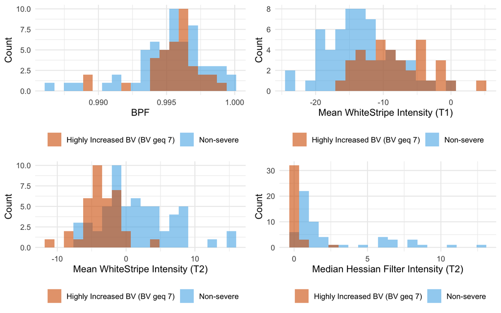

```r
bio_dist_plot(dat_all, threshold = 7)
```

### 4.1.2 Threshold = 6.5

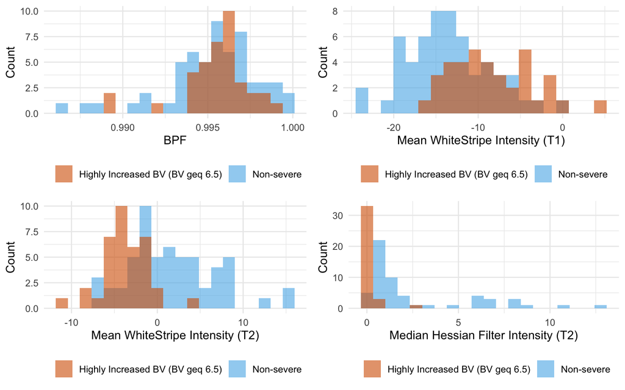

```r
bio_dist_plot(dat_all, threshold = 6.5)
```

### 4.1.3 Threshold = 6

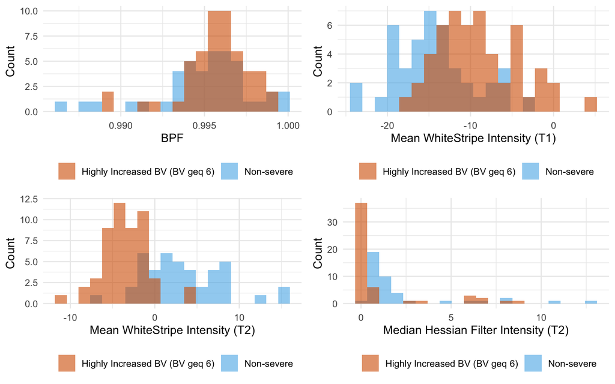

```r
bio_dist_plot(dat_all, threshold = 6)
```

# References

Doshi, Jimit, Guray Erus, Yangming Ou, Bilwaj Gaonkar, and Christos Davatzikos. 2013. “Multi-Atlas Skull-Stripping.” *Academic Radiology* 20 (12): 1566–76. https://doi.org/10.1016/j.acra.2013.09.010.

Frangi, Alejandro F, Wiro J Niessen, Koen L Vincken, and Max A Viergever. 1998. “Multiscale Vessel Enhancement Filtering.” In *International Conference on Medical Image Computing and Computer-Assisted Intervention*, 130–37. Springer.

Shinohara, Russell T., Elizabeth M. Sweeney, Jeff Goldsmith, Navid Shiee, Farrah J. Mateen, Peter A. Calabresi, Samson Jarso, Dzung L. Pham, Daniel S. Reich, and Ciprian M. Crainiceanu. 2014. “Statistical Normalization Techniques for Magnetic Resonance Imaging.” *NeuroImage: Clinical* 6: 9–19. https://doi.org/10.1016/j.nicl.2014.08.008.

Smith, Stephen M. 2002. “Fast Robust Automated Brain Extraction.” *Human Brain Mapping* 17 (3): 143–55. https://doi.org/10.1002/hbm.10062.

Tu, Danni, Manu S. Goyal, Jordan D. Dworkin, Samuel Kampondeni, Lorenna Vidal, Eric Biondo-Savin, Sandeep Juvvadi, et al. 2020. “Automated Analysis of Low-Field Brain MRI in Cerebral Malaria,” December. https://doi.org/10.1101/2020.12.23.424020.

Tustison, Nicholas J, Brian B Avants, Philip A Cook, Yuanjie Zheng, Alexander Egan, Paul A Yushkevich, and James C Gee. 2010. “N4itk: Improved N3 Bias Correction.” *IEEE Transactions on Medical Imaging* 29 (6): 1310–20. https://doi.org/10.1109/tmi.2010.2046908.